# DESARROLLO DE UNA METODOLOGÍA PARA EVALUAR EL DESEMPEÑO TÉRMICO DE VIVIENDAS EN MÉXICO, CASO DE ESTUDIO: SAN FRANCISCO DE CAMPECHE

- Show All Code
- Hide All Code

Author

Erick Jahir Romo Eligio

Published

Invalid Date

# 1 Introducción

## 1.1 Antecedentes

El sector residencial constituye una parte significativa del consumo energético a nivel global y nacional. En 2023, representó el 22.88% del consumo final de energía en el mundo, mientras que en México alcanzó el 15.65% (1). Dentro de este sector, aproximadamente el 35% de la electricidad en las viviendas de México se destina a lograr condiciones de confort térmico, particularmente en regiones de clima cálido, donde la cifra aumenta al 50% (2). No obstante, el acceso a sistemas de enfriamiento sigue siendo limitado: en 2024 únicamente el 21% de los hogares disponian de aire acondicionado, y menos de la mitad de estos se localizan en zonas de clima extremadamente cálido (3).

Según (4), en el verano de 2018 los hogares ubicados en la región cálida de México consumieron 4 veces más energía que en el resto del país. Este elevado consumo representa un gasto energético y económico significativo tanto para los usuarios como para el gobierno, ya que el 20 % de la población concentra el 40 % de los subsidios destinados a la electricidad. Por un lado, existen hogares que requieren un uso intensivo de energía y enfrentan facturas de electricidad muy elevadas para poder habitar sus viviendas; por otro, se encuentran aquellas más vulnerables, que carecen de la solvencia económica para costear sistemas de climatización, lo que repercute directamente en su calidad de vida.

Diversos autores han propuesto estrategias bioclimáticas adaptadas a distintas condiciones ambientales; sin embargo, su efectividad en cada vivienda depende de características constructivas y de ocupación específicas. En otras palabras, la implementación de una estrategia bioclimática no garantiza por sí misma un buen desempeño térmico. Para evaluar con rigor su viabilidad es necesario recurrir a simulaciones de transferencia de calor, las cuales requieren información detallada sobre la vivienda, sus patrones de uso y su contexto climático. Aquí surge una limitante fundamental: en México no existe una base de datos suficientemente completa, actualizada y estandarizada que permita realizar simulaciones energéticas representativas para distintos tipos de viviendas.

Frente a este vacío, se vuelve indispensable avanzar hacia el desarrollo de una metodología clara y sistemática que permita obtener, procesar y organizar la información necesaria para realizar simulaciones energéticas confiables. Dicha metodología debe ser replicable, de modo que pueda aplicarse en diferentes ciudades; actualizable, para incorporar nuevos datos o mejoras; y reescalable, capaz de ampliarse desde estudios locales hasta análisis regionales o nacionales.

En este sentido, la presente investigación se enfoca en diseñar y documentar una metodología replicable, actualizable y reescalable para la construcción de una base de datos destinada a simulaciones energéticas de viviendas en México. Como caso de estudio se selecciona la ciudad de San Francisco de Campeche, ya que resulta ser una ciudad vulnerable en términos de pobreza energética y privación de medios para alcanzar el confort energético según los resultados de (5). Esta metodología busca integrar información climática, constructiva, energética y de ocupación, con el fin de apoyar evaluaciones rigurosas sobre el desempeño térmico de las viviendas y el potencial de estrategias bioclimáticas adaptadas al contexto mexicano.

## 1.2 Objetivos

Desarrollar una metodología replicable, actualizable y reescalable, para procesar datos abiertos para realizar simulaciones energéticas de viviendas en México para evaluar el desempeño térmico, considerando perfiles de consumo energético, ocupación y con y sin el uso de acondicionamiento de aire y el bioclima.

Objetivos particulares:

- Identificar y recabar fuentes de datos abiertos relacionados con el consumo energético, horarios y las características de las viviendas en México
- Procesar los datos abiertos para identificar los perfiles de consumo energético, ocupación y características constructivas de las viviendas en México y completar los datos, de ser necesario, usando un algoritmo de Machine learning.
- Definir las métricas de análisis de desempeño térmico
- Identificar una ciudad vulnerable en términos de confort térmico como caso de estudio
- Conocer cuáles son las estrategías bioclimáticas más efectivas para la ciudad seleccionada
- Realizar simulaciones energéticas para los grupos más representativos (25%, 50%, 75%), con y sin estrategías bioclimáticas
- Desarrollar una WebApp para explorar esta base de datos.
- Documentar y publicar la metodología y la app

## 1.3 Revisión bibliográfica

# 2 Metodología

La metodología propuesta contiene los siguientes pasos:

1. Delimitar el alcance del estudio
2. Escoger fuentes de datos abiertos
3. Seleccionar las variables útiles
4. Determinar el consumo eléctrico mensual en kWh
5. Agrupar las viviendas según sus caracteristicas
6. Obtención de las orientaciones de las fachadas
7. Reescalado de datos a nivel de manzana

## 2.1 Delimitar el alcance del estudio

Lo primero que se recomienda es definir el alcance del estudio, ya sea que se analice una ciudad, un estado o toda la República Mexicana. La metodología presentada en este trabajo está diseñada para ser replicable, actualizable y escalable, de modo que los pasos descritos pueden adaptarse con facilidad al contexto específico del análisis que se desea realizar.

## 2.2 Escoger fuentes de datos abiertos

En lo referente a fuentes de datos abiertos, lo mejor con lo que contamos es con los datos del Instituto Nacional de Estadística y Geografía (INEGI). Entre sus datos se destacan tres encuestas y un censo:

- Encuesta Nacional de Consumo de Energía en Viviendas (ENCEVI): La ENCEVI se levantó durante el primer semestre de 2018, con el objetivo de conocer los patrones de consumo de las distintas fuentes de energía utilizadas para el consumo en las viviendas así como los hábitos y las prácticas en el manejo de energéticos. Esta encuesta incluye datos detallados acerca del número de equipos eléctricos y electrónicos dentro de las viviendas, así como su tiempo de uso a la semana, además, estos datos fueron utilizados por (4) para estimar los consumos eléctricos. Desafortunadamente, solo se realizó una vez en 2018. Se encuentra disponible en (6)
- Encuesta Nacional de Ingresos y Gastos de los Hogares (ENIGH): La encuesta se llevó a cabo del 21 de agosto al 28 de noviembre de 2024, con el objetivo de ofrecer un panorama estadístico del comportamiento de los ingresos y gastos de los hogares, considerando su magnitud, procedencia y distribución. La ENIGH se realiza cada dos años desde 2016, y en esta última edición se incorporaron además datos sobre la infraestructura y el equipamiento de las viviendas. Por estas razones, los datos de esta encuesta se utilizarán como insumo para el modelo de Machine Learning destinado a predecir el consumo eléctrico. Los datos de esta encuesta se encuentran en (7)
- Encuesta Nacional sobre Uso del Tiempo (ENUT): La ENUT 2024 busca generar información estadística sobre las distintas formas de trabajo, remunerado y no remunerado, la producción doméstica, el uso del tiempo y la percepción del bienestar de la población de 12 años y más en áreas urbanas, rurales e indígenas. Con la información contenida en esta encuesta, será posible obtener perfiles de ocupación para entre semana y fines de semana. La ENUT se encuentra disponible en (8)
- Censo de Población y Vivienda 2020: Se realizó del 2 al 27 de marzo donde se visitaron cada una de las viviendas para contar a la población e indagar sobre sus principales características demográficas, socioeconómicas y culturales. El censo será muy útil para correlacionar datos de municipios en particular. Los datos están disponibles en (9).

En las fuentes mencionadas algunos datos se reportan a nivel de vivienda y otros a nivel de hogar, por ello es importante distinguirlos, la INEGI define ambos como:

- Vivienda particular: Construida o adaptada para el alojamiento de personas que forman hogares, y que en el momento del levantamiento puede estar habitada por uno o más hogares, o deshabitada. (10)
- El hogar censal es la unidad formada por una o más personas, vinculadas o no por lazos de parentesco, que residen habitualmente en la misma vivienda particular. (11)

Los datos se reportaran a nivel de vivienda, ya que a pesar que una vivienda pueda contener múltiples hogares, hay datos que no podemos separar en hogares, por ejemplo el número de habitaciones, la superficie de construcción, etc. En ese sentido, se considerará como si todos los hogares en una vivienda representaran un solo hogar grande.

A pesar de que varias encuestas se levanten en los mismos periodos, los datos obtenidos no se pueden correlacionar directamente a nivel de individuo, hogar o vivienda, ya que cada encuesta tiene su propio marco muestral y su propio levantamiento. Es decir, las encuestas no entrevistan a las mismas personas ni usan un identificador común que permita correlacionarse una a una. Por estas razones, es necesario encontrar características que comparten ambas encuestas para poder separar grupos.

## 2.3 Selección y descripción las variables útiles

En las encuestas y el censo seleccionados se identifican múltiples variables. Por un lado, existen aquellas que aportan información directamente útil para las simulaciones energéticas Figura 1. Por otro lado, se encuentran las variables que describen las características de las viviendas y de sus ocupantes Figura 1, las cuales, aunque no se utilicen de forma directa en las simulaciones, resultan esenciales para clasificar las viviendas en grupos con características comunes y así permitir el rescalado de los datos. .

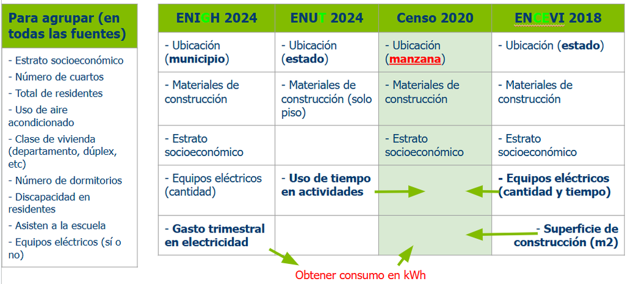

Variables útiles, del lado izquierdo aparecen las variables para agrupar y del lado derecho en negritas las que contienen características que se desea reescalar

### 2.3.4 Limpieza de datos

Criterios para limpiar los datos:

- Se deben desechar los datos con datos faltantes
- Se deben tirar los datos con un periodo facturado diferente a 1 o 2 meses
- Se deben tirar los datos de las viviendas que no tengan acceso a la red de la CFE
- Reportar un pago mensual menor al mínimo

Se recomienda primero contabilizar los datos que se van a tirar en una tabla.

Una característica particularmente útil es el consumo eléctrico mensual en kWh, para determinar estos valores se desarrolló la siguiente sección.

## 2.4 Determinar el consumo eléctrico mensual en kWh

Una de las variables que se desea reescalar es el consumo eléctrico de las viviendas, ya que estos datos permiten calibrar las simulaciones y asegurar que el consumo modelado represente adecuadamente el estado inicial de cada vivienda. Con ello es posible comparar los cambios en el consumo energético al implementar diferentes estrategias bioclimáticas.

Sin embargo, la obtención de datos de consumo eléctrico en México representa un desafío, ya que esta información no se encuentra abierta al público. Ante esta limitación, algunos autores, como (4), han desarrollado estudios para obtener los consumos eléctricos a partir de datos como el monto pagado y la ubicación a nivel de municipio

Para estimar el consumo eléctrico [kWh] en las viviendas, se utilizará una metodología basada en la propuesta por (4), ya que en 2018 estimaron el consumo de energía con datos de la ENCEVI y de la ENIGH de 2018.

La metodología para estimar el consumo electrico consiste en:

1. Determinar la periodicidad del gasto
2. Estimar las tarifas
3. Calcular impuestos incluidos
4. Considerar si fue taria de verano
5. Estimación de subsidios
   1. Asignar bloques tarifarios
   2. Elegir como completar los datos
6. Calcular el consumo en kWh/mes
   1. Para la tarifa 1F
   2. Para la tarifa DAC
7. Completar los datos
   1. Propuesta 1
   2. P2
   3. P3

### 2.4.1 Determinar la periodicidad del gasto

Como se describió anteriormente, primero necesitamos conocer la periodicidad del pago que reportaron los encuestados. En el caso de la ENIGH, se preguntó la fecha (año y mes) en la que realizó el pago del último recibo, así como el número de meses que abarca y el monto. También muestran el gasto trimestral, que según [ENIGH], se encuentra normalizado a la decena de levantamiento para comparar los gastos en un mismo semestre, no se encontró información relacionada con el proceso de normalización; al explorar los datos, salio a la luz que en el caso de los gastos relacionados con la energía eléctrica para periodos de 1 o 2 meses, el gasto trimestral resultó de multiplicar el gasto mensual por 3, al no realizar ajustes relacionados con el cambio de tarifa en verano o fuera de él (más adelante se explica la relevancia de esto), se utilizará el monto del último recibo, la fecha y los meses que abarca. La distribución del número de meses que cubre cada recibo para todo México se muestra a continuación:

```python
periodos_final  # sin index=False porque Quarto ignora ese parámetro
```

Tabla 1: Distribución de viviendas según número de meses que abarca el recibo para consumo eléctrico reportado, para todo México.

|  | Meses | Viviendas | % |
| --- | --- | --- | --- |
| 0 | 1 | 1118287.0 | 2.92 |
| 1 | 2 | 33012860.0 | 86.07 |
| 2 | 3–80 | 375691.0 | 0.98 |
| 3 | Sin datos | 3849204.0 | 10.04 |

### 2.4.2 Estimar las tarifas

Según la Ley de la Industria Eléctrica (13) artículo 12 sección V, la Comisión Reguladora de Energía (CRE) está facultada para expedir y aplicar las metodologías para determinar y ajustar las tarifas y los precios máximos de la industria eléctrica.

Mientras que la CFE administra el esquema de tarifas eléctricas en México, compuesto por ocho tipos de tarifas residenciales que varían en costos, impuestos, subsidios y niveles de consumo. Siete de estas tarifas operan bajo un sistema de bloques crecientes, en el cual, conforme aumenta el consumo, el usuario progresa a bloques con precios más altos y subsidios reducidos; la octava tarifa es la doméstica de alto consumo (DAC), la cual tiene un cargo fijo y un costo por cada kWh; todas las tarifas cambian de acuerdo al mes y sobre todo entre temporada de verano y fuera de verano. En el caso de la ENIGH, no se preguntó a los encuestados la tarifa que cada uno tiene, por lo que es necesario continuar con la metodología propuesta por (4) para determinarla. Eso consiste en solicitar a la CFE los datos de las tarifas más frecuentes en cada municipio y a partir de ello asignarlas a cada encuestado. También es útil buscar en internet en caso de que haya existido algún acuerdo entre un gobierno estatal y la CFE.

### 2.4.3 Calcular impuestos incluidos

Además del resultante del pago por consumo de electricidad, la CFE recaba el pago de los siguientes impuestos:

- Impuesto sobre el Valor Añadido (IVA): Del 16% del consumo para todo México.
- Derecho al Alumbrado Público (DAP): El DAP varía según el municipio y lo calcula la CFE mediante uno de cuatro métodos diferentes o la combinación de 2 o más de ellos. Hay que recordar que el DAP es un impuesto para el gobierno de cada municipio, pero es recaudado por la CFE, para conocer el DAP, hay que buscar en las leyes de hacienda de cada estado.

### 2.4.4 Considerar si fue taria de verano

En la Figura 2 se muestra un ejemplo del cambio en las tarifas al iniciar la temporada de verano. En 2024, para la tarifa 1F, los límites de consumo de los bloques aumentaron diez veces al pasar de marzo (fuera de verano) a abril (en periodo de verano). Asimismo, el precio del bloque básico se redujo en 25.3 %, mientras que el del bloque intermedio disminuyó en 23.7 %.

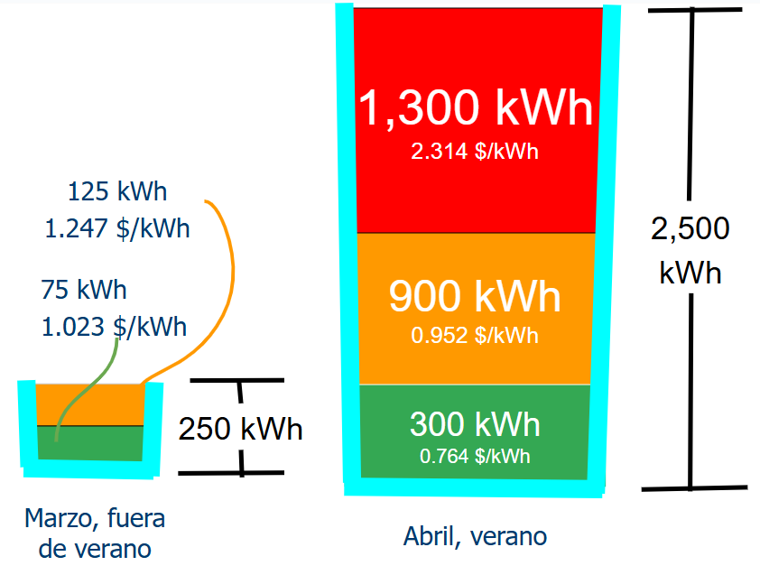

Ejemplo de las tarifas 1F de 2024: del lado izquierdo se muestra un mes fuera de verano (marzo) y del lado derecho un mes en periodo de verano (abril). El consumo dentro de los límites de cada bloque se representa mediante vasos: a medida que el vaso se va llenando, se avanza al siguiente bloque y los costos aumentan. Cuando el consumo rebasa el límite superior, el vaso se desborda, lo que corresponde al cobro por excedentes o a la transición hacia la tarifa DAC

Esto implica que un mismo monto pagado en marzo representa un consumo de energía menor que si se hubiera pagado ese mismo monto en abril. En consecuencia, asignar incorrectamente el periodo tarifario a los gastos reportados en la encuesta puede llevar a subestimar o sobreestimar el consumo eléctrico real de las viviendas.

Para determinar la temporada tarifaria correspondiente a cada pago, es necesario estimar el **mes de la tarifa aplicable** en cada caso. Aunque los costos de cada bloque dentro de una misma tarifa cambian de un mes a otro, y los periodos facturados suelen abarcar varios meses del calendario, cada uno con costos distintos, la CFE no prorratea estos cambios. En su lugar, aplica únicamente los costos del mes tarifario asignado al recibo, y con esos costos calcula tanto la energía consumida como los cargos asociados de todo el periodo facturado. Por ello, identificar correctamente el mes tarifario es fundamental para estimar de manera precisa el consumo eléctrico.

Para determinar el mes de la tarifa aplicable necesitamos conocer la fecha de corte, la cual es la fecha en la que se realizó la lectura del medidor de cada vivienda. Sin embargo, en la ENIGH no se preguntó por el día de corte, pero se puede aproximar. Según (15), el plazo legal mínimo para realizar el pago es de 10 días naturales, además, en (16) se señala que el mes de la tarifa aplicable se obtiene de la siguiente manera: Para facturación mensual, es la tarifa que se encuentre vigente 15 días naturales antes de la fecha de corte. En facturación bimestral, la tarifa aplicable es aquella que se encuentre vigente 30 días naturales antes de la fecha de corte.

Por lo tanto, la tarifa aplicable para la facturación mensual será aquella que estuviera vigente 25 días antes de la fecha de pago. Dado que la ENIGH no reporta el día exacto del pago, para las viviendas con facturación mensual, se asume que el pago ocurrió dentro de los primeros 25 días del mes, ya que esto es estadísticamente más probable: la probabilidad de pagar entre el día 1 y el 25 es del 83.33%, mientras que pagar entre el día 26 y el 30 corresponde únicamente al 16.67%. Bajo esta suposición, la tarifa aplicable suele ser la del mes anterior (si el pago ocurriera realmente en los últimos cinco días del mes, la tarifa vigente sería la del mismo mes).

Para la facturación bimestral, la tarifa aplicable corresponde a la que estaba vigente 40 días antes del pago. Nuevamente, al desconocerse el día exacto, se asume que los pagos se realizaron entre los días 11 y 30, lo cual tiene una probabilidad del 66.67%, frente al 33.33% de haber pagado entre el día 1 y el 10. Con esta suposición, la tarifa aplicable también suele ser la del mes anterior. (si el pago hubiera ocurrido en los primeros diez días, la tarifa vigente correspondería al mes antepasado).

### 2.4.5 Estimación de subsidios

Por un lado tenemos el subsidio federal a la electricidad, el cual es financiado por la Secretaría de Hacienda y Crédito Público (SHCP) (17) y se aplica de manera nacional a todas las tarifas domésticas (1, 1A–1F). Este subsidio forma parte de la estructura tarifaria regulada por la CRE y aparece como “apoyo gubernamental” en los recibos, reduciendo el precio por kWh en cada bloque de consumo.

Por otro lado, el subsidio estatal corresponde a una aportación adicional que puede otorgar cada gobierno estatal, independiente del subsidio federal, con el propósito de reducir aún más el costo de la electricidad para los usuarios de su entidad. Este subsidio es temporal, local y puede variar tanto en porcentaje como en su método de aplicación; por ello, es necesario investigar cómo cada administración estatal asigna y distribuye dicho presupuesto, en caso de que exista.

Cabe destacar que la tarifa de Alto Consumo (DAC) es la única que no recibe subsidio, ni estatal ni federal.

Si el caso de estudio no cuenta con subsidio estatal, se puede continuar directamente con la asignación de bloques tarifarios, el cálculo del consumo y, posteriormente, la imputación de los datos faltantes.

En caso de que sí exista un subsidio estatal aplicable al caso de estudio, es indispensable documentar su mecanismo de distribución. Si esta información no está disponible, se recomienda establecer suposiciones justificadas y realizar análisis de sensibilidad para evaluar el impacto de dichas suposiciones.

#### 2.4.5.1 Asignar bloques tarifarios

La clasificación de viviendas por bloque tarifario se realiza comparando el monto mensual pagado por energía eléctrica con el costo equivalente a los límites de consumo de cada bloque. Como se mencionó anteriormente, la CFE determina el cobro a partir de los kWh consumidos. Para la tarifa 1F en verano de 2024, la estructura es la siguiente:

- Bloque básico: primeros 300 kWh, cobrados al precio más bajo.
- Intermedio bajo: siguientes 900 kWh.
- Intermedio alto: siguientes 1300 kWh.
- Excedente: cualquier consumo por arriba de estos límites (más de 2500 kWh). Tras tres periodos consecutivos pagando excedentes, el usuario pasa a tarifa DAC.

Sin embargo, a partir de los datos disponibles no es posible distinguir qué viviendas están pagando excedentes ni cuáles ya pertenecen formalmente a la tarifa DAC. Por ello, los bloque se asignan de la siguiente manera:

1. Bloque básico: Si el pago reportado es menor o igual al costo equivalente a 300 kWh y mayor al costo mínimo (equivalente a 25 kWh), la vivienda se clasifica en este bloque.
2. Bloque intermedio bajo: Si el monto es mayor al costo equivalente a 300 kWh (límite del bloque básico) y no rebasa el de 1200 kWh, se asigna a este bloque.
3. Bloque intermedio alto: Si el monto es mayor al costo equivalente a 1200 kWh (límites de los bloques básico + intermedio bajo) y no supera el de 2500 kWh, se asigna a este bloque.
4. Tarifa DAC: Si el monto reportado supera el costo equivalente a 2500 kWh, se clasificará a la vivienda como usuario DAC.

El monto reportado por cada vivienda se compara con los costos equivalentes a estos rangos para determinar su asignación al bloque correspondiente. Como ejemplo, los costos de los límites de consumo para el periodo de verano, incluyendo los impuestos del 22% se muestran en la Table 6.

Para las viviendas que reportaron un gasto fuera de la temporada de verano, se aplica el mismo procedimiento general, pero considerando que la estructura tarifaria contempla únicamente dos bloques y la tarifa DAC:

1. Bloque básico: Si el pago reportado es menor o igual al costo equivalente a 75 kWh y mayor al costo mínimo (equivalente a 25 kWh), la vivienda se clasifica en este bloque.
2. Bloque intermedio: Si el monto es mayor al costo equivalente a 75 kWh (límite del bloque básico) y no rebasa el de 125 kWh, se asigna a este bloque.
3. Tarifa DAC: Si el monto reportado supera el costo equivalente a 125 kWh, se clasificará a la vivienda como usuario DAC.

El monto reportado por cada vivienda se compara con los costos equivalentes a estos rangos para determinar su asignación al bloque correspondiente. Como ejemplo, los costos de los límites de consumo para el periodo fuera de verano, incluyendo los impuestos del 22% se muestran en la Table 7

#### 2.4.5.2 Elegir como completar los datos

### 2.4.6 Calcular el consumo en kWh/mes

#### 2.4.6.1 Para la tarifa 1F

#### 2.4.6.2 Para la tarifa DAC

### 2.4.7 Completar los datos

#### 2.4.7.1 Propuesta 1

#### 2.4.7.2 P2

#### 2.4.7.3 P3

## 2.5 Definir las tipologías de las viviendas

## 2.6 Obtención de las orientaciones de las fachadas

## 2.7 Reescalado de datos a nivel de manzana

# 3 Completar datos

# 4 Caracterización de la vivienda en el caso de estudio (San Francisco de Campeche)

## 4.1 Delimitar el alcance del estudio

En primer lugar, en (5) se desarrolló un índice de privación energética que evaluó diez capitales representativas de los distintos bioclimas de México. En dicho análisis, Oaxaca de Juárez y San Francisco de Campeche fueron identificados como las dos ciudades más vulnerables de ese grupo en términos de pobreza energética y confort térmico. Es importante señalar que el estudio de (5) no tuvo como propósito determinar cuál es la ciudad más vulnerable del país, y tampoco este trabajo persigue dicho objetivo. Por ello, la elección de esta ciudad responde a que se trata de una ciudad vulnerable, aunque no necesariamente la más vulnerable de México.

Las fuentes de datos abiertos y las variables escogidas son las mismas que aparecen en la metodología

## 4.2 Determinar el consumo eléctrico mensual en kWh

En este caso de estudio, nos encontramos con que el gobierno del estado de Campeche asignó un subsidio estatal a la electricidad en un periodo que coincide con parte del levantamiento de la encuesta ENIGH 2024, al no encontrar información de la repartición a nivel de municipio para el caso de estudio, se tuvo que calcular el consumo para todo el estado.

### 4.2.1 Determinar la periodicidad del gasto

Como se puede ver en Table 2 en el caso de Campeche, las facturas mensuales representaron el 1.51%, mientras que las bimestrales el 88.79%. Por otro lado, es necesario desechar el otro 1.08%, ya que estos sugieren que las viviendas que los reportaron tienen deudas de periodos anteriores, y no es posible distinguir entre el monto que corresponde a la deuda o a servicios de reconexión del monto del consumo de electricidad, así mismo, se desecha el 8.62% por no reportar gastos en energía eléctrica.

```python
# Incluir los NaN en el groupby usando dropna=False
periodos = (
    edo_df_sucio
    .groupby('num_meses', dropna=False)['factor']
    .sum()
    .reset_index()
)

# Renombrar columnas
periodos.columns = ['meses', 'conteo']

# Convertir 'meses' a tipo adecuado:
# - números enteros para valores válidos
# - texto "NaN" para los faltantes
periodos['meses'] = periodos['meses'].apply(
    lambda x: int(x) if pd.notna(x) else "Sin datos"
)

# Calcular porcentajes
periodos['%'] = periodos['conteo'] / edo_df_sucio['factor'].sum() * 100
periodos['%'] = periodos['%'].round(2)

# Separar categoría "Sin dato"
nan_row = periodos.loc[periodos['meses'] == "Sin datos"].copy()
periodos_sin_nan = periodos.loc[periodos['meses'] != "Sin datos"].copy()

# Ordenar los datos válidos
periodos_sin_nan = periodos_sin_nan.sort_values('meses').reset_index(drop=True)

# Separar primeras dos filas (1 y 2 meses)
primeras = periodos_sin_nan.loc[periodos_sin_nan['meses'].isin([1, 2])].copy()

# Agrupar de 3 a 80 meses
resto = periodos_sin_nan.loc[periodos_sin_nan['meses'] >= 3].copy()

# Crear fila acumulada
fila_acumulada = {
    'meses': '3–80',
    'conteo': resto['conteo'].sum(),
    '%': round(resto['conteo'].sum() / edo_df_sucio['factor'].sum() * 100, 2)
}

fila_acumulada_df = pd.DataFrame([fila_acumulada])

# Unir todo: 1 mes, 2 meses, 3–80 meses y finalmente NaN
periodos_final = pd.concat([primeras, fila_acumulada_df, nan_row], ignore_index=True)

# Renombrar columnas finales
periodos_final_edo = periodos_final.rename(columns={
    'conteo': 'Viviendas',
    'meses': 'Meses',
})
```

```python
periodos_final_edo  # sin index=False porque Quarto ignora ese parámetro
```

Tabla 2: Distribución de viviendas según número de meses que abarca el recibo para consumo eléctrico reportado en el estado de Campeche.

|  | Meses | Viviendas | % |
| --- | --- | --- | --- |
| 0 | 1 | 4074 | 1.51 |
| 1 | 2 | 240210 | 88.79 |
| 2 | 3–80 | 2923 | 1.08 |
| 3 | Sin datos | 23320 | 8.62 |

```python
# TIRADAS por tener un periodo raro
periodos_final_edo['Viviendas'].sum() - GASTOVIV_luz_edo['factor'].sum()
```

```
np.float64(20204.0)
```

### 4.2.2 Estimar las tarifas

En nuestro caso de estudio, para 2024 CFE y el gobierno de Campeche llegaron a un acuerdo (14), en el que en todo el estado solo se tuvo la tarifa 1F, la cual representa los costos más bajos. En Table 3 y Table 4 se pueden observar los costos que tuvieron las tarifas 1F obtenidos de (18). Asi mismo, en la Table 5 se muestran los precios de la tarifa DAC para 2024 obtenidos de (19)

```python
parametros = {
    "enero": {
        "min_men": 1.015 * 25 * 1.22,
        "basico": 1.015 * 75 * 1.22,
        "intermedio": 1.239 * 125 * 1.22
    },
    "febrero": {
        "min_men": 1.019 * 25 * 1.22,
        "basico": 1.019 * 75 * 1.22,
        "intermedio": 1.243 * 125 * 1.22
    },
    "marzo": {
        "min_men": 1.023 * 25 * 1.22,
        "basico": 1.023 * 75 * 1.22,
        "intermedio": 1.247 * 125 * 1.22
    },
    "abril": {
        "min_men": 0.764 * 25 * 1.22,
        "basico": 0.764 * 300 * 1.22,
        "intermedio_bajo": 0.952 * 900 * 1.22,
        "intermedio_alto": 2.314 * 1300 * 1.22
    },
    "mayo": {
        "min_men": 0.767 * 25 * 1.22,
        "basico": 0.767 * 300 * 1.22,
        "intermedio_bajo": 0.955 * 900 * 1.22,
        "intermedio_alto": 2.322 * 1300 * 1.22
    },
    "junio": {
        "min_men": 0.770 * 25 * 1.22,
        "basico": 0.770 * 300 * 1.22,
        "intermedio_bajo": 0.958 * 900 * 1.22,
        "intermedio_alto": 2.330 * 1300 * 1.22
    },
    "julio": {
        "min_men": 0.773 * 25 * 1.22,
        "basico": 0.773 * 300 * 1.22,
        "intermedio_bajo": 0.961 * 900 * 1.22,
        "intermedio_alto": 2.338 * 1300 * 1.22
    },
    "agosto": {
        "min_men": 0.776 * 25 * 1.22,
        "basico": 0.776 * 300 * 1.22,
        "intermedio_bajo": 0.964 * 900 * 1.22,
        "intermedio_alto": 2.346 * 1300 * 1.22
    },
    "septiembre": {
        "min_men": 0.779 * 25 * 1.22,
        "basico": 0.779 * 300 * 1.22,
        "intermedio_bajo": 0.967 * 900 * 1.22,
        "intermedio_alto": 2.354 * 1300 * 1.22
    },
    "octubre": {
        "min_men": 1.051 * 25 * 1.22,
        "basico": 1.275 * 75 * 1.22,
        "intermedio": 3.737 * 125 * 1.22,
    },
    "noviembre": {
        "min_men": 1.055 * 25 * 1.22,
        "basico": 1.280 * 75 * 1.22,
        "intermedio": 3.750 * 125 * 1.22,
    },
    "diciembre": {
        "min_men": 1.059 * 25 * 1.22,
        "basico": 1.059 * 75 * 1.22,
        "intermedio": 1.285 * 125 * 1.22
    },
}

verano = ["abril","mayo","junio","julio","agosto","septiembre"]
no_verano = ["enero","febrero","marzo", "octubre", "noviembre", "diciembre"]
```

```python
verano = ["abril","mayo","junio","julio","agosto","septiembre"]
no_verano = ["enero","febrero","marzo", "octubre", "noviembre", "diciembre"]


# Función para obtener costo y límite
def obtener_costo_y_limite(mes, clave, valor):
    if clave == "basico":
        limite = 300 if mes in verano else 75
        return round(valor / (limite * 1.22), 3), limite

    if clave == "intermedio_bajo":
        return round(valor / (900 * 1.22), 3), 900

    if clave == "intermedio_alto":
        return round(valor / (1300 * 1.22), 3), 1300

    if clave == "intermedio":  # no verano
        return round(valor / (125 * 1.22), 3), 125

    return None, None


# Orden solicitado
orden_bloques = ["basico", "intermedio_bajo", "intermedio_alto", "intermedio"]


# Construcción de tablas
def construir_tabla(meses_lista):
    tabla = pd.DataFrame()
    filas = []

    # Determinar qué bloques existen en estos meses
    for bloque in orden_bloques:
        if any(bloque in parametros[mes] for mes in meses_lista):
            filas.append(bloque)

    tabla["Bloque"] = filas

    # Diccionario para límites
    limites = {bloque: None for bloque in filas}

    # LLENAR COSTOS POR MES
    for mes in meses_lista:
        columna = f"Costo {mes} [$/kWh]"
        tabla[columna] = None

        for i, bloque in enumerate(tabla["Bloque"]):
            if bloque in parametros[mes]:
                costo, limite = obtener_costo_y_limite(mes, bloque, parametros[mes][bloque])
                tabla.loc[i, columna] = costo

                # Guardar límite solo la primera vez
                if limites[bloque] is None:
                    limites[bloque] = limite

    # AGREGAR LÍMITE AL FINAL
    tabla["Límite de consumo [kWh]"] = tabla["Bloque"].map(limites)

    return tabla


# Crear tablas finales
tarifas_verano = construir_tabla(verano)
tarifas_no_verano = construir_tabla(no_verano)
```

```python
tarifas_verano
```

Tabla 3: Costos de la tarifa 1F en 2024 para el periodo de verano

|  | Bloque | Costo abril [$/kWh] | Costo mayo [$/kWh] | Costo junio [$/kWh] | Costo julio [$/kWh] | Costo agosto [$/kWh] | Costo septiembre [$/kWh] | Límite de consumo [kWh] |
| --- | --- | --- | --- | --- | --- | --- | --- | --- |
| 0 | basico | 0.764 | 0.767 | 0.77 | 0.773 | 0.776 | 0.779 | 300 |
| 1 | intermedio_bajo | 0.952 | 0.955 | 0.958 | 0.961 | 0.964 | 0.967 | 900 |
| 2 | intermedio_alto | 2.314 | 2.322 | 2.33 | 2.338 | 2.346 | 2.354 | 1300 |

```python
tarifas_no_verano
```

Tabla 4: Costos de la tarifa 1F en 2024 para el periodo fuera de verano

|  | Bloque | Costo enero [$/kWh] | Costo febrero [$/kWh] | Costo marzo [$/kWh] | Costo octubre [$/kWh] | Costo noviembre [$/kWh] | Costo diciembre [$/kWh] | Límite de consumo [kWh] |
| --- | --- | --- | --- | --- | --- | --- | --- | --- |
| 0 | basico | 1.015 | 1.019 | 1.023 | 1.275 | 1.28 | 1.059 | 75 |
| 1 | intermedio | 1.239 | 1.243 | 1.247 | 3.737 | 3.75 | 1.285 | 125 |

```python
# Parámetros DAC
parametros_DAC = {
    "enero":     {"cargo_fijo": 130.77, "cargo_kWh": 5.416},
    "febrero":   {"cargo_fijo": 130.52, "cargo_kWh": 5.337},
    "marzo":     {"cargo_fijo": 131.07, "cargo_kWh": 5.366},
    "abril":     {"cargo_fijo": 131.78, "cargo_kWh": 5.139},
    "mayo":      {"cargo_fijo": 131.71, "cargo_kWh": 5.125},
    "junio":     {"cargo_fijo": 131.95, "cargo_kWh": 5.151},
    "julio":     {"cargo_fijo": 132.57, "cargo_kWh": 5.391},
    "agosto":    {"cargo_fijo": 134.94, "cargo_kWh": 5.631},
    "septiembre":{"cargo_fijo": 135.21, "cargo_kWh": 5.436},
    "octubre":   {"cargo_fijo": 136.70, "cargo_kWh": 5.450},
    "noviembre": {"cargo_fijo": 138.45, "cargo_kWh": 5.826},
    "diciembre": {"cargo_fijo": 138.98, "cargo_kWh": 5.733},
}

# Construir tabla DAC
def construir_tabla_DAC(parametros):
    tabla = pd.DataFrame({"Concepto": ["Cargo fijo [MXN]", "Cargo por energía [$/kWh]"]})

    for mes, valores in parametros.items():
        tabla[f"{mes}"] = [valores["cargo_fijo"], valores["cargo_kWh"]]

    return tabla

# Generar tabla
tarifas_dac = construir_tabla_DAC(parametros_DAC)
```

```python
tarifas_dac
```

Tabla 5: Costos de la tarifa DAC en 2024

|  | Concepto | enero | febrero | marzo | abril | mayo | junio | julio | agosto | septiembre | octubre | noviembre | diciembre |
| --- | --- | --- | --- | --- | --- | --- | --- | --- | --- | --- | --- | --- | --- |
| 0 | Cargo fijo [MXN] | 130.770 | 130.520 | 131.070 | 131.780 | 131.710 | 131.950 | 132.570 | 134.940 | 135.210 | 136.70 | 138.450 | 138.980 |
| 1 | Cargo por energía [$/kWh] | 5.416 | 5.337 | 5.366 | 5.139 | 5.125 | 5.151 | 5.391 | 5.631 | 5.436 | 5.45 | 5.826 | 5.733 |

### 4.2.3 Calcular impuestos incluidos

Para el Derecho de Alumbrado Público (DAP), en el caso de estudio considerado en esta metodología, se tomó como referencia lo establecido en la Ley de Hacienda de los Municipios del Estado de Campeche (20). En dicho documento se especifica que:

“La tarifa mensual correspondiente al derecho de alumbrado público, será obtenida como resultado de dividir el costo anual global general actualizado erogado por el Municipio en la prestación de este servicio, entre el número de usuarios registrados en la Comisión Federal de Electricidad y el número de predios rústicos o urbanos detectados que no están registrados en la Comisión Federal de Electricidad. El resultado será dividido entre 12 y lo que dé como resultado de esta operación se cobrará en cada recibo que la Comisión Federal de Electricidad expida y su monto no podrá ser superior al 6% de las cantidades que deban pagar los contribuyentes en forma particular, sobre el consumo de energía eléctrica.”

Dado que la ley establece un límite del 6 % del consumo de energía eléctrica, en este estudio se adopta dicho valor como un cargo fijo para calcular el DAP de cada vivienda encuestada. Asimismo, tal como se indicó previamente en la metodología, se incorpora también el 16 % correspondiente al IVA.

Por lo tanto, el monto total de impuestos considerado para este análisis asciende al 22 % del consumo eléctrico bruto.

### 4.2.4 Considerar si fue taria de verano

Siguiendo la metodología previamente descrita, se determinaron los meses de tarifa aplicables para las viviendas del estado de Campeche. En la Figure 1 se presenta la distribución de dichas tarifas a lo largo del año. Entre las viviendas con información suficiente para estimar su consumo, el 98.05 % reportó un pago correspondiente a una tarifa de verano, mientras que el 1.95 % restante declaró un pago fuera del periodo de verano.

Es importante señalar que estos valores representan únicamente a las viviendas con datos adecuados para calcular su consumo: aquellas con periodos facturados de uno o dos meses, datos completos y con conexión a la red eléctrica de la CFE.

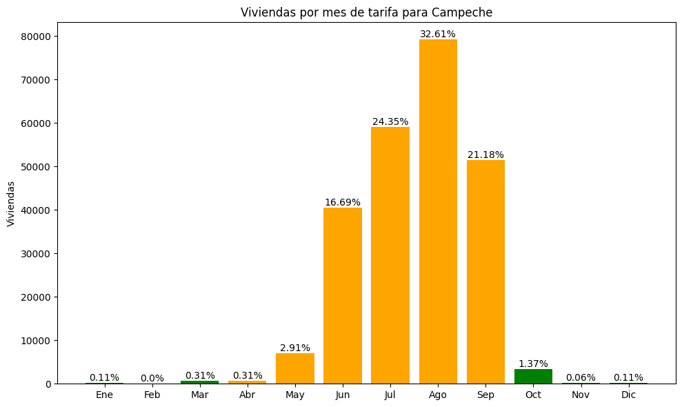

Figura 1: Distribución de meses de la tarifa aplicable para el estado de Campeche para las viviendas con datos suficientes para calcular el consumo. Las barras naranjas representan el periodo de verano y las verdes el periodo fuera de verano.

```python
plt.figure(figsize=(10,6))
bars = plt.bar(range(12), tabla_plot["Viviendas"], color=colores)

plt.xticks(ticks=range(12), labels=meses_esp_abrev)
plt.ylabel("Viviendas")
plt.title("Viviendas por mes de tarifa para Campeche")

for bar, pct in zip(bars, tabla_plot["Porcentaje (%)"]):
    height = bar.get_height()
    plt.text(
        bar.get_x() + bar.get_width() / 2,
        height,
        f"{pct}%",
        ha="center", va="bottom"
    )

plt.tight_layout()
plt.show()
```

### 4.2.5 Estimación de subsidios

En el caso de Campeche, según (21), en 2024 se destinó 70 millones de pesos para este fin, pudiendo representar hasta el 50% del consumo, hay que recordar que el apoyo por el subsidio estatal disminuye conforme aumenta el consumo. Sin embargo, no hay un medio oficial en el que se detalle cómo se repartió ese subsidio en 2024, pero en el documento (21) especifica que en 2023 se repartió el subsidio solo a quienes tuvieron un consumo de bloque básico, y en esta metodología trabajaremos con la suposición de que en 2024 también se repartió de esa manera, es decir, quienes tuvieron un consumo menor a 300 kWh recibieron hasta el 50% de apoyo.

Como se observó en la sección anterior, el 98.05% de las viviendas encuestadas declararon un pago de electricidad efectuado en temporada de verano. El siguiente paso consiste en determinar cuántas de estas viviendas pertenecen a cada uno de los bloques tarifarios, en particular al bloque básico, ya que es este grupo el que recibió el subsidio estatal.

### 4.2.6 Asignar bloques tarifarios

Como se explicó en la sección de metodología, la asignación de bloques tarifarios se basa en los costos límite, es decir, el monto máximo que una vivienda puede pagar para permanecer dentro de un bloque específico. Estos valores representan el costo correspondiente al consumo en el límite superior de cada bloque. Los costos límite utilizados en este análisis se presentan en la tabla Table 6 y Table 7.

```python
verano = ["abril","mayo","junio","julio","agosto","septiembre"]
no_verano = ["enero","febrero","marzo", "octubre", "noviembre", "diciembre"]

# ---- Renombres de columnas ----
renombres = {
    "min_men": "mínimo mensual [MXN]",
    "basico": "básico [MXN]",
    "intermedio_bajo": "intermedio bajo [MXN]",
    "intermedio_alto": "intermedio alto [MXN]",
    "intermedio": "intermedio [MXN]"
}

# ---- Función para generar tablas y ordenar columnas ----
def crear_tabla(meses, parametros):
    columnas = set()
    for mes in meses:
        columnas.update(parametros[mes].keys())
    columnas = sorted(columnas)

    tabla = pd.DataFrame([
        {"Mes": mes, **{col: parametros[mes].get(col, np.nan) for col in columnas}}
        for mes in meses
    ])

    tabla = tabla.rename(columns=renombres)

    # Orden correcto de columnas
    columnas_finales = ["Mes"]
    if "mínimo mensual [MXN]" in tabla.columns:
        columnas_finales.append("mínimo mensual [MXN]")

    for col in ["básico [MXN]", "intermedio bajo [MXN]", "intermedio alto [MXN]", "intermedio [MXN]"]:
        if col in tabla.columns:
            columnas_finales.append(col)

    tabla = tabla[columnas_finales]
    return tabla


# ---- Crear tablas con nombres solicitados ----
tabla_lim_verano = crear_tabla(verano, parametros)
tabla_lim_no_verano = crear_tabla(no_verano, parametros)

tabla_lim_verano["intermedio bajo [MXN]"] = tabla_lim_verano["intermedio bajo [MXN]"] + tabla_lim_verano["básico [MXN]"]
tabla_lim_verano["intermedio alto [MXN]"] = tabla_lim_verano["intermedio bajo [MXN]"] + tabla_lim_verano["intermedio alto [MXN]"]

tabla_lim_no_verano["intermedio [MXN]"] = tabla_lim_no_verano["básico [MXN]"] + tabla_lim_no_verano["intermedio [MXN]"]
```

```python
tabla_lim_verano
```

Tabla 6: Costos límites para el periodo de verano. Se presentan en pesos mexicanos [MXN] del 2024, el valor en mes representa el mes de la tarifa aplicable incluyendo el 22% de impuestos.

|  | Mes | mínimo mensual [MXN] | básico [MXN] | intermedio bajo [MXN] | intermedio alto [MXN] |
| --- | --- | --- | --- | --- | --- |
| 0 | abril | 23.3020 | 279.624 | 1324.920 | 4994.924 |
| 1 | mayo | 23.3935 | 280.722 | 1329.312 | 5012.004 |
| 2 | junio | 23.4850 | 281.820 | 1333.704 | 5029.084 |
| 3 | julio | 23.5765 | 282.918 | 1338.096 | 5046.164 |
| 4 | agosto | 23.6680 | 284.016 | 1342.488 | 5063.244 |
| 5 | septiembre | 23.7595 | 285.114 | 1346.880 | 5080.324 |

```python
tabla_lim_no_verano
```

Tabla 7: Costos límites para el periodo fuera de verano. Se presentan en pesos mexicanos [MXN] del 2024, el valor en mes representa el mes de la tarifa aplicable incluyendo el 22% de impuestos

|  | Mes | mínimo mensual [MXN] | básico [MXN] | intermedio [MXN] |
| --- | --- | --- | --- | --- |
| 0 | enero | 30.9575 | 92.8725 | 281.820 |
| 1 | febrero | 31.0795 | 93.2385 | 282.796 |
| 2 | marzo | 31.2015 | 93.6045 | 283.772 |
| 3 | octubre | 32.0555 | 116.6625 | 686.555 |
| 4 | noviembre | 32.1775 | 117.1200 | 688.995 |
| 5 | diciembre | 32.2995 | 96.8985 | 292.861 |

```python
def get_bloque(row):

    mes = row["mes_tarifa_nombre"]

    # Si no existe en el diccionario o es NaN, devolver NaN
    if mes not in parametros:
        return np.nan
    elif mes in verano:
        # Obtener parámetros del mes
        min_men = parametros[mes]["min_men"]
        basico = parametros[mes]["basico"]
        intermedio_bajo = parametros[mes]["intermedio_bajo"]
        intermedio_alto = parametros[mes]["intermedio_alto"]

        gasto = row["gasto_mes"]

        if gasto <= min_men:
            return np.nan
        elif gasto <= basico:
            return "basico"
        elif gasto <= basico + intermedio_bajo:
            return "intermedio_bajo"
        elif gasto <= basico + intermedio_bajo + intermedio_alto:
            return "intermedio_alto"
        else:
            return "DAC"

    elif mes in no_verano:
        # Obtener parámetros del mes
        min_men = parametros[mes]["min_men"]
        basico = parametros[mes]["basico"]
        intermedio = parametros[mes]["intermedio"]

        gasto = row["gasto_mes"]

        # Clasificación según umbrales del mes correspondiente
        if gasto <= min_men:
            return np.nan
        elif gasto <= basico:
            return "basico"
        elif gasto <= basico + intermedio:
            return "intermedio"
        else:
            return "DAC"
```

```python
edo_df = edo_df.copy()
edo_df["bloque"] = edo_df.apply(get_bloque, axis=1)
```

En las gráficas Figure 2 y Figure 3 se presentan las proporciones de viviendas clasificadas en cada bloque tarifario para los periodos de verano y fuera de verano. Como se observa, durante el verano la mayoría de las viviendas se ubican en el bloque intermedio bajo (color naranja), con un 53.32 %, seguido del bloque básico (color verde), que concentra el 29.47 % de las viviendas.

Es importante destacar que el bloque básico corresponde a las viviendas que recibieron el subsidio estatal durante 2024; por esta razón, no es posible calcular directamente su consumo en esta etapa del análisis. En contraste, sí se puede estimar de manera directa el consumo del 71.19 % de las viviendas con datos suficientes, lo que equivale al 63.9 % del total de registros antes del proceso de limpieza.

También es importante señalar que las viviendas que aparecen en la columna gris, clasificadas como sin bloque, corresponden a casos en los que se reportó un gasto inferior al mínimo posible según la tarifa vigente. Debido a que estos valores son inconsistentes con la estructura tarifaria de la CFE, estos datos fueron desechados durante el proceso de limpieza.

```python
# Copia para graficar y asegurar que Viviendas sea numérica
verano = ["abril","mayo","junio","julio","agosto","septiembre"]

df_verano = edo_df.loc[edo_df['mes_tarifa_nombre'].isin(verano)]

viv_verano = df_verano.loc[edo_df['bloque'].notna(), 'factor'].sum()
DACs_verano = df_verano.loc[df_verano['bloque'] == 'DAC', 'factor'].sum()
basico_verano = df_verano.loc[df_verano['bloque'] == 'basico', 'factor'].sum()
int_bajo_verano = df_verano.loc[df_verano['bloque'] == 'intermedio_bajo', 'factor'].sum()
int_bajo_alto = df_verano.loc[df_verano['bloque'] == 'intermedio_alto', 'factor'].sum()
bloque_nan_verano = df_verano.loc[df_verano['bloque'].isna(), 'factor'].sum()

# --- Crear tabla ---
tabla_verano = pd.DataFrame({
    "Bloque": ["basico", "intermedio_bajo", "intermedio_alto", 'DAC', "sin bloque"],

    "Viviendas": [
        basico_verano, int_bajo_verano, int_bajo_alto, DACs_verano, bloque_nan_verano
    ]
})

# --- Porcentajes respecto al total calculable ---
tabla_verano["Porcentaje (%)"] = (tabla_verano["Viviendas"] / viv_verano * 100).round(2)

# --- Formato con separador de miles ---
tabla_verano["Viviendas"] = tabla_verano["Viviendas"].apply(lambda x: f"{int(x):,}")

tabla_plot = tabla_verano.copy()
tabla_plot["Viviendas"] = tabla_plot["Viviendas"].replace({",": ""}, regex=True).astype(int)

colores = ['green','orange','red','purple','gray']
```

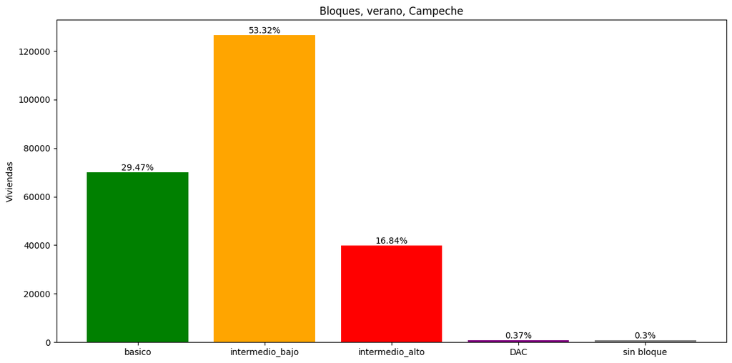

Figura 2: Distribución de los bloques tarifarios a los que pertenecen las viviendas del estado de Campeche en el periodo de verano, porcentajes para las viviendas con datos suficientes para calcular el consumo.

```python
plt.figure(figsize=(12,6))
bars = plt.bar(tabla_plot["Bloque"], tabla_plot["Viviendas"], color=colores)

# plt.xticks(rotation=45)
plt.ylabel("Viviendas")
plt.title("Bloques, verano, Campeche")

# Agregar los porcentajes arriba de cada barra
for bar, pct in zip(bars, tabla_plot["Porcentaje (%)"]):
    height = bar.get_height()
    plt.text(
        bar.get_x() + bar.get_width()/2,
        height,
        f"{pct}%",
        ha="center", va="bottom"
    )

plt.tight_layout()
plt.show()
```

```python
no_verano = ["enero","febrero","marzo", "octubre", "noviembre", "diciembre"]

df_verano = edo_df.loc[edo_df['mes_tarifa_nombre'].isin(no_verano)]

viv_verano = df_verano.loc[edo_df['bloque'].notna(), 'factor'].sum()
DACs_verano = df_verano.loc[df_verano['bloque'] == 'DAC', 'factor'].sum()
basico_verano = df_verano.loc[df_verano['bloque'] == 'basico', 'factor'].sum()
int_verano = df_verano.loc[df_verano['bloque'] == 'intermedio', 'factor'].sum()
bloque_nan_verano = df_verano.loc[df_verano['bloque'].isna(), 'factor'].sum()

# --- Crear tabla ---
tabla_no_verano = pd.DataFrame({
    "Bloque": ["basico", "intermedio", 'DAC', "sin bloque"],

    "Viviendas": [
        basico_verano, int_verano, DACs_verano, bloque_nan_verano
    ]
})

# --- Porcentajes respecto al total calculable ---
tabla_no_verano["Porcentaje (%)"] = (tabla_no_verano["Viviendas"] / viv_verano * 100).round(2)

# --- Formato con separador de miles ---
tabla_no_verano["Viviendas"] = tabla_no_verano["Viviendas"].apply(lambda x: f"{int(x):,}")

# Copia para graficar y asegurar que Viviendas sea numérica
tabla_plot = tabla_no_verano.copy()
tabla_plot["Viviendas"] = tabla_plot["Viviendas"].replace({",": ""}, regex=True).astype(int)

# Meses que deben eir en color naranja
# meses_naranja = ["abril", "mayo", "junio", "julio", "agosto", "septiembre"]

# # Asignar color a cada barra
colores = ['green','orange','purple','gray']
```

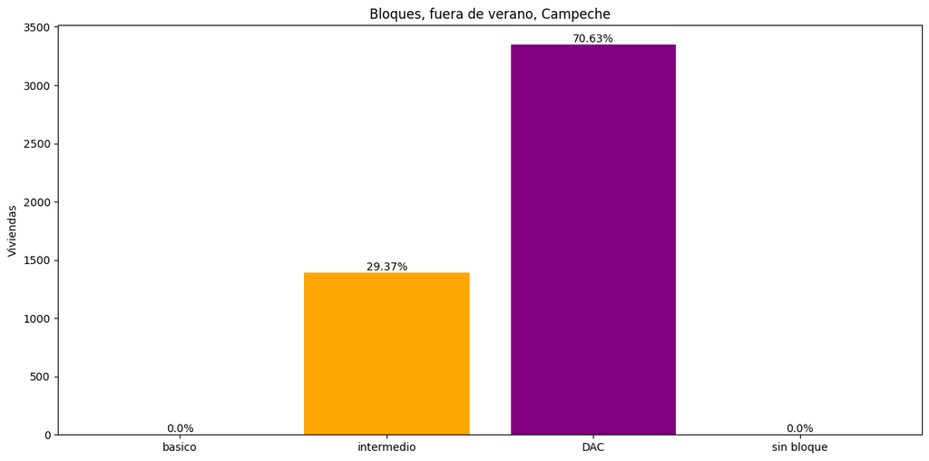

Figura 3: Distribución de los bloques tarifarios a los que pertenecen las viviendas del estado de Campeche en el periodo fuera de verano, porcentajes para las viviendas con datos suficientes para calcular el consumo.

```python
# Crear la gráfica
plt.figure(figsize=(12,6))
bars = plt.bar(tabla_plot["Bloque"], tabla_plot["Viviendas"]
               , color=colores
              )

# plt.xticks(rotation=45)
plt.ylabel("Viviendas")
plt.title("Bloques, fuera de verano, Campeche")

# Agregar los porcentajes arriba de cada barra
for bar, pct in zip(bars, tabla_plot["Porcentaje (%)"]):
    height = bar.get_height()
    plt.text(
        bar.get_x() + bar.get_width()/2,
        height,
        f"{pct}%",
        ha="center", va="bottom"
    )

plt.tight_layout()
plt.show()
```

### 4.2.7 Resumen, limpieza de datos

Al depurar los datos siguiendo los criterios descritos anteriormente, se obtuvieron los resultados mostrados en la Table 8. En este caso de estudio, tras aplicar todos los filtros, se conservaron 242,834 viviendas, lo que representa el 89.76% del total inicial.

La razón por la que el porcentaje real de datos conservados es mayor es que, al aplicar los criterios de forma simultánea, los datos descartados no son equivalentes a la suma directa de los porcentajes individuales. Esto ocurre porque algunas viviendas cumplen más de un criterio de descarte. Por ejemplo, hay viviendas sin acceso a la electricidad que, además, no registraron datos de gastos por consumo eléctrico, por lo que son contabilizadas en más de una categoría dentro de la tabla.

```python
tabla_tirados
```

Tabla 8: Valores desechados debido a diferentes criterios

[output not shown]

## References

1.

Subsecretaría de Planeación y Transición Energética. Balance nacional de energía 2023 [Internet]. 2025. Available from: https://www.gob.mx/cms/uploads/attachment/file/977268/Balance_Nacional_de_Energ_a_2023.FINAL06.02.2025.1.pdf

2.

Buen O de. Eficiencia energética en el confort térmico en viviendas de clima cálido en méxico [Internet]. México: CONUEE; 2025. Available from: https://www.conuee.gob.mx/transparencia/boletines/Cuadernos/cuaderno5nvociclo.pdf

3.

INEGI. Encuesta nacional de ingresos y gastos de los hogares (ENIGH) 2024 [Internet]. Instituto Nacional de Estadística y Geografía; 2025. Available from: https://www.inegi.org.mx/programas/enigh/nc/2024/#documentacion

4.

Hernandez M, Patiño-Echeverri D. Classifying residential electricity demand in mexico using random forest and multinomial logistic regression. In: Proceedings of the 2019 FISE-IEEE/CIGRE conference – living the energy transition (FISE/CIGRE) [Internet]. Medellín, Colombia; 2019. Available from: https://www.scopus.com/pages/publications/85082481144

5.

Cedano KG, Robles-Bonilla T, Santillán OS, Martínez M. Assessing energy poverty in urban regions of mexico: The role of thermal comfort and bioclimatic context. Sustainability [Internet]. 2021;13(19). Available from: https://doi.org/10.3390/su131910646

6.

INEGI. Encuesta nacional sobre consumo de energéticos en viviendas particulares (ENCEVI) 2018 [Internet]. México: Instituto Nacional de Estadı́stica y Geografı́a; 2018. Available from: https://www.inegi.org.mx/programas/encevi/2018/

7.

INEGI. Encuesta nacional de ingresos y gastos de los hogares (ENIGH) 2024 [Internet]. México: Instituto Nacional de Estadı́stica y Geografı́a; 2025. Available from: https://www.inegi.org.mx/programas/enigh/nc/2024/

8.

INEGI. Encuesta nacional sobre uso del tiempo (ENUT) 2024 [Internet]. México: Instituto Nacional de Estadı́stica y Geografı́a; 2025. Available from: https://www.inegi.org.mx/programas/enut/2024/

9.

INEGI. Censo de población y vivienda 2020 [Internet]. México: Instituto Nacional de Estadı́stica y Geografı́a; 2020. Available from: https://www.inegi.org.mx/programas/ccpv/2020/

10.

INEGI. Glosario de la encuesta nacional sobre consumo de energéticos en viviendas particulares (ENCEVI) 2018 [Internet]. Instituto Nacional de Estadística y Geografía; 2018. Available from: https://www.inegi.org.mx/app/glosario/default.html?p=ENCEVI_2018

11.

INEGI. Hogares: Definición y conceptos [Internet]. Instituto Nacional de Estadística y Geografía; 2020. Available from: https://www.inegi.org.mx/temas/hogares/

12.

Electricidad CF de. Tarifas domésticas (1, 1A-1F, DAC) [Internet]. Comisión Federal de Electricidad; 2024. Available from: https://app.cfe.mx/Aplicaciones/CCFE/Tarifas/TarifasCRECasa/Tarifas/DEPDomesticas.aspx

13.

Diputados del H. Congreso de la Unión C de. Ley de la industria eléctrica [Internet]. Diario Oficial de la Federación; 2021. Available from: https://portalhcd.diputados.gob.mx/LeyesBiblio/pdf/LIElec_090321.pdf

14.

Estado de Campeche G del. Conoce tu tarifa [Internet]. Gobierno del Estado de Campeche; 2024. Available from: https://www.semabicce.campeche.gob.mx/2024/02/19/conoce-tu-tarifa/

15.

Electricidad CF de. Programa de certificados bursátiles de corto y largo plazo con carácter revolvente. Monto total autorizado del programa: $100,000’000,000.00 (cien mil millones de pesos 00/100 m.n.) o su equivalente en unidades de inversión [Internet]. Comisión Federal de Electricidad; 2016. Available from: https://www.cfe.gob.mx/finanzas/financiamiento/Documents/Emisiones%20Nacionales/CFE--Programa%20%20CBs%202016--Prospecto%20Colocaci%C3%B3n%20Definitivo.pdf

16.

Energía CR de. Resolución de la comisión reguladora de energía por la que aprueba el modelo de contrato mercantil para la prestación del servicio de suministro básico de energía eléctrica en baja tensión en la modalidad de pospago presentado por CFE suministrador de servicios básicos y su anexo único [Internet]. Diario Oficial de la Federación; 2023. Available from: https://dof.gob.mx/nota_detalle_popup.php?codigo=5628991

17.

Federación AS de la. Subsidios al consumo de energía eléctrica: Informe del resultado de la fiscalización superior de la cuenta pública 2011 [Internet]. México: Secretaría de Hacienda y Crédito Público; 2011. Available from: https://www.asf.gob.mx/Trans/Informes/IR2011i/Grupos/Gobierno/2011_0069_a.pdf

18.

Electricidad CF de. Tarifa 1F [Internet]. Sitio oficial CFE; 2025. Available from: https://app.cfe.mx/aplicaciones/ccfe/tarifas/TarifasCRECasa/Tarifas/Tarifa1F.aspx

19.

Electricidad CF de. Tarifa doméstica de alto consumo (DAC) [Internet]. Sitio oficial CFE; 2025. Available from: https://app.cfe.mx/Aplicaciones/CCFE/Tarifas/TarifasCRECasa/Tarifas/TarifaDAC.aspx

20.

Poder Legislativo del Estado de Campeche, Secretaría General, Dirección de Control de Procesos Legislativos. Ley de hacienda de los municipios del estado de campeche [Internet]. Compendio Jurídico del Estado, Sección Leyes. Documento para consulta sin validez legal; 2022. Available from: https://legislacion.congresocam.gob.mx/index.php/etiquetas-x-materia/490-ley-de-hacienda-de-los-municipios-del-estado-de-campeche/file

21.

Gobierno de Campeche. La gobernadora layda sansores san román firmó el convenio para la reducción del costo de la energía eléctrica para todo el estado [Internet]. El Economista; Available from: https://www.eleconomista.com.mx/politica/La-gobernadora-Layda-Sansores-San-Roman-firmo-el-convenio-para-la-reduccion-del-costo-de-la-energia-electrica-para-todo-el-estado-20231211-0085.html